# STAT 118: Homework A

Intro to RStudio and Quarto

# 1.

Tell me your name in bold lettering. Is there anything I should know about your name and how to address you? (ie. I prefer to be called Liz instead of Elizabeth, my pronouns are he/his/him, etc.)

# 2.

Tell me your major in italics lettering. Any ideas what you might like to do after you graduate? (It’s okay to say you don’t know)

# 3.

Make a list of a few of your interests

# 4.

What is the name of someone sitting near you in class? Include a link to something you both find funny or interesting.

# 5.

Include a picture. This could be a picture of you or a picture of something you find funny or interesting.

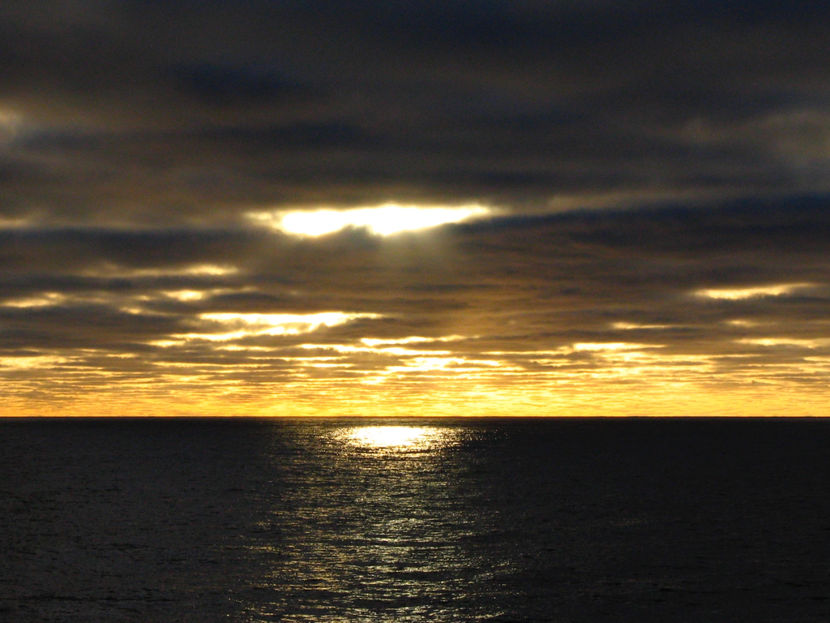

picture test

```r
print(getwd())
```

```
[1] "/Users/caseysmith/Dropbox/!Middlebury/Teaching/STAT 118/S2026/S2026_R_Proj/Homework"
```

# 6.

Create an object called `c`. Decide on a number between 1 and 10 that denotes your comfort level with taking a data science course this semester (10 being that you are so, so excited and 1 being that you almost threw up this morning just thinking about it). Assign this value to `c`.

```r
c <- 6
```

# 7.

Create an object called `height`. Assign your height in inches to this object (you can also use a made up number here if you like). Use R to convert the height to meters. Be sure to comment your code to explain what you are doing.

# 8.

Have you ever taken a class that used R before? If so, which class?

# 9.

Tell me a little about how you feel about taking data science this semester. Are you nervous? Do you feel like this course is out of your comfort zone? Are you confident?

# 11.(Optional)

Use this space below to tell me anything about yourself that you think I should know in order to teach you effectively. You can also use this space below to ask any questions or state any concerns.